# Hyperparameter_Tuning

Author

Clara Jordan

# Lab Set Up

## Libraries

```r
library(dplyr)
library(tidyverse)
library(tidymodels)
library(powerjoin)
library(glue)
library(vip)
library(baguette)
library(visdat)
library(skimr)
library(ggpubr)
library(rsample)
library(patchwork)
```

# 1. Data Import/Tidy/Transform

## Read in the data

```r
root  <- 'https://gdex.ucar.edu/dataset/camels/file'

download.file('https://gdex.ucar.edu/dataset/camels/file/camels_attributes_v2.0.pdf',
              'data/camels_attributes_v2.0.pdf')

types <- c("clim", "geol", "soil", "topo", "vege", "hydro")

# Where the files live online ...
remote_files  <- glue('{root}/camels_{types}.txt')
# where we want to download the data ...
local_files   <- glue('data/camels_{types}.txt')

walk2(remote_files, local_files, download.file, quiet = TRUE)
```

## Merge the data

```r
# Read and merge data
camels <- map(local_files, read_delim, show_col_types = FALSE)
camels <- power_full_join(camels ,by = 'gauge_id')
```

## Data cleaning

```r
# Summary data
summary(camels)
```

```
   gauge_id             p_mean          pet_mean     p_seasonality
 Length:671         Min.   :0.6446   Min.   :1.899   Min.   :-1.43546
 Class :character   1st Qu.:2.3731   1st Qu.:2.335   1st Qu.:-0.26352
 Mode  :character   Median :3.2295   Median :2.688   Median : 0.08093
                    Mean   :3.2577   Mean   :2.787   Mean   :-0.04128
                    3rd Qu.:3.7835   3rd Qu.:3.146   3rd Qu.: 0.22399
                    Max.   :8.9369   Max.   :4.744   Max.   : 0.92202

   frac_snow          aridity       high_prec_freq  high_prec_dur
 Min.   :0.00000   Min.   :0.2203   Min.   : 7.90   Min.   :1.075
 1st Qu.:0.03514   1st Qu.:0.6957   1st Qu.:18.50   1st Qu.:1.209
 Median :0.09793   Median :0.8551   Median :22.00   Median :1.282
 Mean   :0.17760   Mean   :1.0565   Mean   :20.93   Mean   :1.350
 3rd Qu.:0.22306   3rd Qu.:1.2673   3rd Qu.:24.23   3rd Qu.:1.440
 Max.   :0.90633   Max.   :5.2079   Max.   :32.70   Max.   :2.091

 high_prec_timing   low_prec_freq    low_prec_dur    low_prec_timing
 Length:671         Min.   :169.9   Min.   : 2.789   Length:671
 Class :character   1st Qu.:232.7   1st Qu.: 4.241   Class :character
 Mode  :character   Median :255.8   Median : 4.950   Mode  :character
                    Mean   :254.6   Mean   : 5.954
                    3rd Qu.:278.9   3rd Qu.: 6.702
                    Max.   :348.7   Max.   :36.513

 geol_1st_class     glim_1st_class_frac geol_2nd_class     glim_2nd_class_frac
 Length:671         Min.   :0.2967      Length:671         Min.   :0.000000
 Class :character   1st Qu.:0.6083      Class :character   1st Qu.:0.002894
 Mode  :character   Median :0.8294      Mode  :character   Median :0.136540
                    Mean   :0.7855                         Mean   :0.155426
                    3rd Qu.:0.9971                         3rd Qu.:0.266373
                    Max.   :1.0000                         Max.   :0.489930

 carbonate_rocks_frac geol_porostiy     geol_permeability soil_depth_pelletier
 Min.   :0.00000      Min.   :0.01000   Min.   :-16.50    Min.   : 0.2667
 1st Qu.:0.00000      1st Qu.:0.06767   1st Qu.:-14.77    1st Qu.: 1.0000
 Median :0.00000      Median :0.13190   Median :-13.96    Median : 1.2283
 Mean   :0.11874      Mean   :0.12637   Mean   :-13.89    Mean   :10.8728
 3rd Qu.:0.04333      3rd Qu.:0.18623   3rd Qu.:-13.00    3rd Qu.:12.8894
 Max.   :1.00000      Max.   :0.28000   Max.   :-10.90    Max.   :50.0000
                      NA's   :3
```

[output cut: 65 more lines]

```
 Min.   :  0.000   Min.   : 0.000   Min.   :  0.00   Min.   :  0.00
 1st Qu.:  6.412   1st Qu.: 1.821   1st Qu.: 37.44   1st Qu.: 10.00
 Median : 15.100   Median : 2.848   Median : 96.00   Median : 15.52
 Mean   : 25.745   Mean   : 6.913   Mean   :107.62   Mean   : 22.28
 3rd Qu.: 35.788   3rd Qu.: 7.554   3rd Qu.:162.14   3rd Qu.: 26.91
 Max.   :172.800   Max.   :92.559   Max.   :356.80   Max.   :209.88
 NA's   :1         NA's   :1        NA's   :1        NA's   :1
  zero_q_freq         hfd_mean
 Min.   :0.00000   Min.   :112.2
 1st Qu.:0.00000   1st Qu.:160.2
 Median :0.00000   Median :173.8
 Mean   :0.03415   Mean   :182.5
 3rd Qu.:0.00000   3rd Qu.:204.1
 Max.   :0.96537   Max.   :287.8
 NA's   :1         NA's   :1
```

```r
ls(camels)
```

```
 [1] "area_gages2"          "area_geospa_fabric"   "aridity"
 [4] "baseflow_index"       "carbonate_rocks_frac" "clay_frac"
 [7] "dom_land_cover"       "dom_land_cover_frac"  "elev_mean"
[10] "frac_forest"          "frac_snow"            "gauge_id"
[13] "gauge_lat"            "gauge_lon"            "geol_1st_class"
[16] "geol_2nd_class"       "geol_permeability"    "geol_porostiy"
[19] "glim_1st_class_frac"  "glim_2nd_class_frac"  "gvf_diff"
[22] "gvf_max"              "hfd_mean"             "high_prec_dur"
[25] "high_prec_freq"       "high_prec_timing"     "high_q_dur"
[28] "high_q_freq"          "lai_diff"             "lai_max"
[31] "low_prec_dur"         "low_prec_freq"        "low_prec_timing"
[34] "low_q_dur"            "low_q_freq"           "max_water_content"
[37] "organic_frac"         "other_frac"           "p_mean"
[40] "p_seasonality"        "pet_mean"             "q_mean"
[43] "q5"                   "q95"                  "root_depth_50"
[46] "root_depth_99"        "runoff_ratio"         "sand_frac"
[49] "silt_frac"            "slope_fdc"            "slope_mean"
[52] "soil_conductivity"    "soil_depth_pelletier" "soil_depth_statsgo"
[55] "soil_porosity"        "stream_elas"          "water_frac"
[58] "zero_q_freq"
```

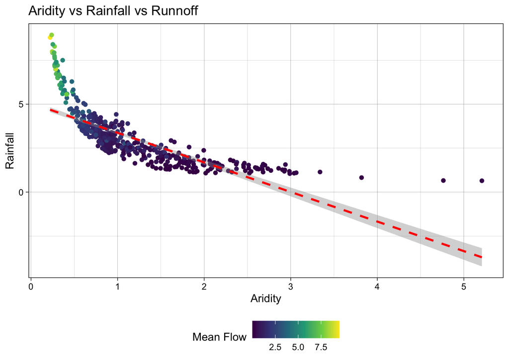

```r
# Data cleaning
camels <- na.omit(camels)

## Visual EDA

# Create a scatter plot of aridity vs rainfall
ggplot(camels, aes(x = aridity, y = p_mean)) +
  # Add points colored by mean flow
  geom_point(aes(color = q_mean)) +
  # Add a linear regression line
  geom_smooth(method = "lm", color = "red", linetype = 2) +
  # Apply the viridis color scale
  scale_color_viridis_c() +
  # Add a title, axis labels, and theme (w/ legend on the bottom)
  theme_linedraw() +
  theme(legend.position = "bottom") +
  labs(title = "Aridity vs Rainfall vs Runnoff",
       x = "Aridity",
       y = "Rainfall",
       color = "Mean Flow")
```

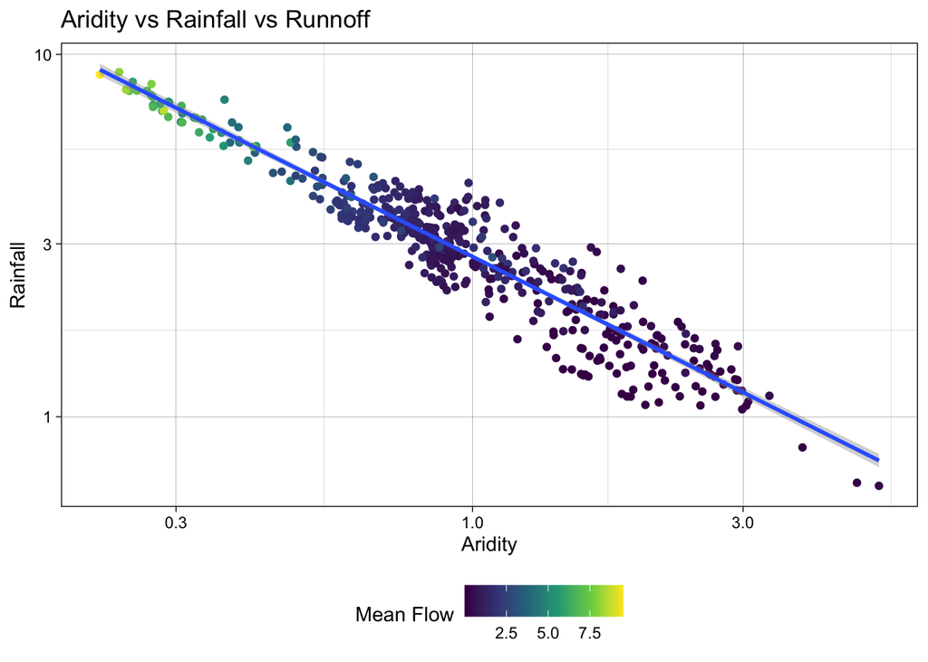

```r
## Visual EDA with transformation
ggplot(camels, aes(x = aridity, y = p_mean)) +
  geom_point(aes(color = q_mean)) +
  geom_smooth(method = "lm") +
  scale_color_viridis_c() +
  # Apply log transformations to the x and y axes
  scale_x_log10() +
  scale_y_log10() +
  theme_linedraw() +
  theme(legend.position = "bottom") +
  labs(title = "Aridity vs Rainfall vs Runnoff",
       x = "Aridity",
       y = "Rainfall",
       color = "Mean Flow")
```

## Data splitting

```r
# Set Seed
set.seed(456654)

# Bad form to perform simple transformations on the outcome variable within a recipe. So, we'll do it here.
camels <- camels |>
  mutate(logQmean = log(q_mean))

# Generate the split
camels_split <- initial_split(camels, prop = 0.8)
camels_train <- training(camels_split)
camels_test  <- testing(camels_split)

# Build resamples
camels_cv <- vfold_cv(camels_train, v = 10)
```

# 2. Feature Engineering

## Creating a recipe

```r
# Create a recipe to preprocess the data
rec <-  recipe(logQmean ~ aridity + p_mean, data = camels_train) %>%
  # Log transform the predictor variables (aridity and p_mean)
  step_log(all_predictors()) %>%
  # Add an interaction term between aridity and p_mean
  step_interact(terms = ~ aridity:p_mean) |>
  # Drop any rows with missing values in the pred
  step_naomit(all_predictors(), all_outcomes())
```

# 3. Resampling and Model Testing

## Build 3 candidate models

```r
# Define Regression Models
xgb_model <- boost_tree() |>
  set_engine("xgboost") |>
  set_mode("regression")

dt_model <- decision_tree() |>
  set_engine("rpart") |>
  set_mode("regression")

ranger_rf_model <- rand_forest() |>
  set_engine("ranger") |>
  set_mode("regression")
```

## Test the models

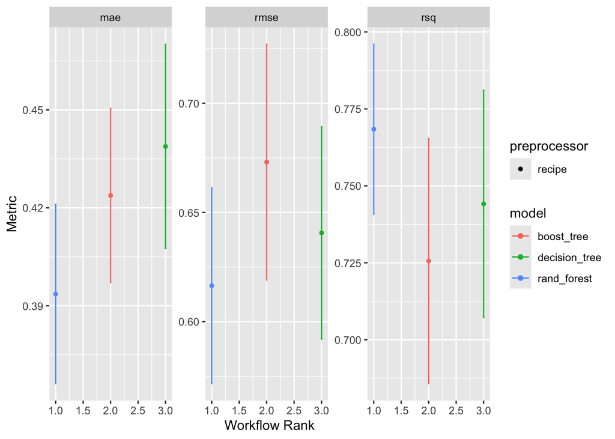

```r
wf <- workflow_set(list(rec), list(boost  = xgb_model,
                                  dt       = dt_model,
                                  ranger   = ranger_rf_model)) |>
  workflow_map(resamples = camels_cv,
               metrics   = metric_set(mae, rsq, rmse))

autoplot(wf)
```

```r
rank_results(wf, rank_metric = "rsq", select_best = TRUE)
```

```
# A tibble: 9 × 9
  wflow_id      .config     .metric  mean std_err     n preprocessor model  rank
  <chr>         <chr>       <chr>   <dbl>   <dbl> <int> <chr>        <chr> <int>
1 recipe_ranger Preprocess… mae     0.394  0.0167    10 recipe       rand…     1
2 recipe_ranger Preprocess… rmse    0.616  0.0273    10 recipe       rand…     1
3 recipe_ranger Preprocess… rsq     0.768  0.0168    10 recipe       rand…     1
4 recipe_dt     Preprocess… mae     0.439  0.0190    10 recipe       deci…     2
5 recipe_dt     Preprocess… rmse    0.641  0.0296    10 recipe       deci…     2
6 recipe_dt     Preprocess… rsq     0.744  0.0225    10 recipe       deci…     2
7 recipe_boost  Preprocess… mae     0.424  0.0162    10 recipe       boos…     3
8 recipe_boost  Preprocess… rmse    0.673  0.0328    10 recipe       boos…     3
9 recipe_boost  Preprocess… rsq     0.726  0.0242    10 recipe       boos…     3
```

# 4. Model Selection

## Selected model description

The model selected is a random forest model with type random forest, mode regression, and engine ranger. I think it is performing well for this problem because the simplicity of the model and high predictive accuracy is adequate for determining logQmean. Additionally, random forest models are robust to overfitting.

# 5. Model Tuning

## A. Build a model for your chosen specification.

```r
forest_tune <- rand_forest(trees = tune(), min_n = tune()) |>
  set_engine("ranger") |>
  set_mode("regression")
```

## B. Create a workflow

```r
wf_tune <- workflow(rec,
                    rand_forest(mode       = "regression",
                               engine     = "ranger",
                               trees      = tune(),
                               min_n      = tune()))

wf_tune = workflow() |>
  add_recipe(rec) |>
  add_model(forest_tune)
```

## C. Check tunable ranges/values

```r
dials <- extract_parameter_set_dials(wf_tune)
dials$object
```

```
[[1]]
# Trees (quantitative)
Range: [1, 2000]

[[2]]
Minimal Node Size (quantitative)
Range: [2, 40]
```

## Define the search space

```r
my.grid <- dials |>
  update(trees = trees(c(1, 2000))) |>
  grid_latin_hypercube(size = 25)
```

# 5B. Tune the Model

## Run model parameters

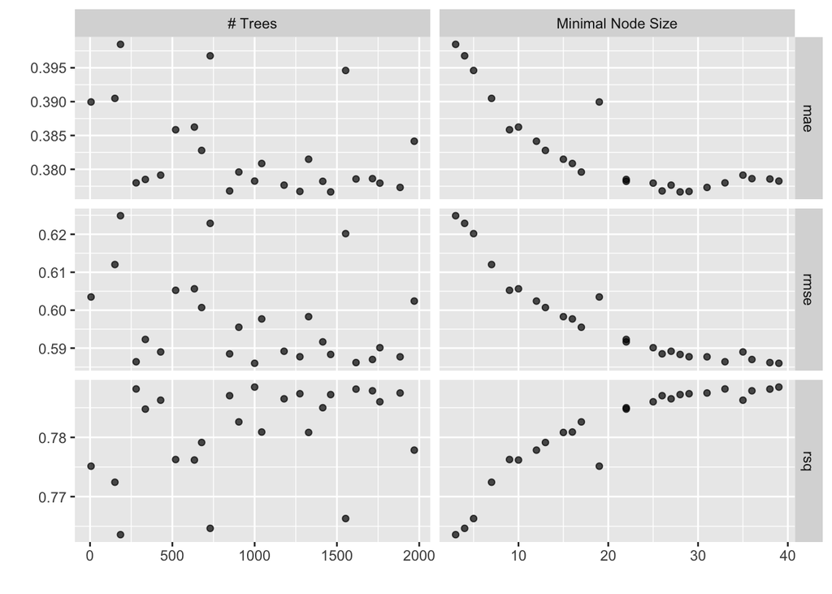

```r
model_params <-  tune_grid(
    wf_tune,
    resamples = camels_cv,
    grid = my.grid,
    metrics = metric_set(rmse, rsq, mae),
    control = control_grid(save_pred = TRUE)
  )

autoplot(model_params)
```

## Description

I see that as minimal node size increases, mae decreases. Similarly, as minimal node size increases, rmse decreases. However, as minimal node size increases so does rsq. There seems to be no relationship between the number of trees and mae, rmse, and rsq.

# Check the skill of the tuned model

## Use the collect_metrics() function to check the skill of the tuned model. Describe what you see, remember dplyr functions like arrange, slice_*, and filter will work on this tibble.

```r
tree_metrics = metric_set(rsq, rmse, mae)

hp_best <- select_best(model_params, metric = "mae")

finalize <- finalize_workflow(wf_tune, hp_best)

final_fit <- last_fit(finalize, camels_split, metrics = tree_metrics)

collect_metrics(final_fit)
```

```
# A tibble: 3 × 4
  .metric .estimator .estimate .config
  <chr>   <chr>          <dbl> <chr>
1 rsq     standard       0.767 Preprocessor1_Model1
2 rmse    standard       0.596 Preprocessor1_Model1
3 mae     standard       0.382 Preprocessor1_Model1
```

## Collect_metrics interpretation

I see that the estimates for rsq, rmse, and mae are all standard using the final fit model. The mae is the lowest of the metrics and the rsq is the highest. The relatively high rsq indicates strong correlation in the model. The relatively low rmse and mae indicates low prediction error.

## Use the show_best() function to show the best performing model based on Mean Absolute Error.

```r
show_best(model_params, metric = "mae")
```

```
# A tibble: 5 × 8
  trees min_n .metric .estimator  mean     n std_err .config
  <int> <int> <chr>   <chr>      <dbl> <int>   <dbl> <chr>
1  1462    28 mae     standard   0.377    10  0.0153 Preprocessor1_Model24
2  1275    29 mae     standard   0.377    10  0.0153 Preprocessor1_Model25
3   848    26 mae     standard   0.377    10  0.0153 Preprocessor1_Model11
4  1884    31 mae     standard   0.377    10  0.0152 Preprocessor1_Model18
5  1179    27 mae     standard   0.378    10  0.0152 Preprocessor1_Model14
```

## Use the select_best() function to save the best performing hyperparameter set to an object called hp_best.

```r
hp_best <- select_best(model_params, metric = "mae")
```

# 7. Finalize Your Model

## Run finalize_workflow() based on your workflow and best hyperparmater set to create a final workflow object.

```r
finalize <- finalize_workflow(wf_tune, hp_best)
```

# 8. Final Model Verification

## Use last_fit() to fit the finalized workflow the original split object (output of initial_split()). This will fit the model to the training data and validate it on the testing data.

```r
final_fit <- last_fit(finalize, camels_split, metrics = tree_metrics)
```

## Use the collect_metrics() function to check the performance of the final model on the test data. This will return a tibble with the metrics for the final model.

```r
collect_metrics(final_fit)
```

```
# A tibble: 3 × 4
  .metric .estimator .estimate .config
  <chr>   <chr>          <dbl> <chr>
1 rsq     standard       0.767 Preprocessor1_Model1
2 rmse    standard       0.597 Preprocessor1_Model1
3 mae     standard       0.382 Preprocessor1_Model1
```

## Use the collect_predictions() function to check the predictions of the final model on the test data. This will return a tibble with the predictions for the final model.

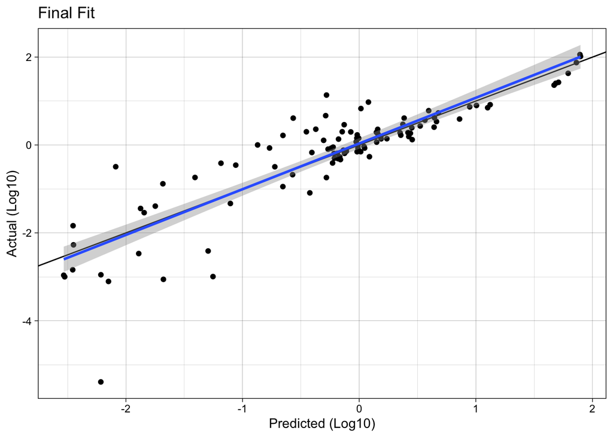

```r
collect_predictions(final_fit) |>
  ggplot(aes(x = .pred, y = logQmean)) +
  geom_point() +
  scale_color_viridis_c() +
  geom_abline() +
  geom_smooth(method = "lm") +
  theme_linedraw() +
  labs(title = "Final Fit",
       x = "Predicted (Log10)",
       y = "Actual (Log10)")
```

# Final Step: Building a Map

## This full fit can be passed to the augment() function to make predictions on the full, cleaned data. This will return a tibble with the predictions for the full data.

```r
full_pred = fit(finalize, data = camels) |>
  augment(new_data = camels)
```

## Use the mutate() function to calculate the residuals of the predictions. The residuals are the difference between the predicted values and the actual values squared.

```r
residuals <- full_pred |>
  mutate(residuals=(.pred-logQmean)^2)
```

## Use ggplot2 to create a map of the predictions.

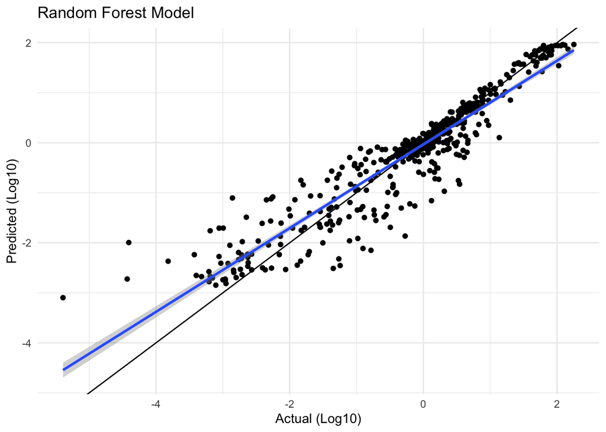

```r
ggplot(full_pred, aes(x = logQmean, y = .pred)) +
  geom_point() +
  geom_abline() +
  geom_smooth(method = "lm") +
  labs(title = "Random Forest Model",
       x = "Actual (Log10)",
       y = "Predicted (Log10)", subtitle = ) +
  theme_minimal()
```

## Use ggplot2 to create a map of the residuals

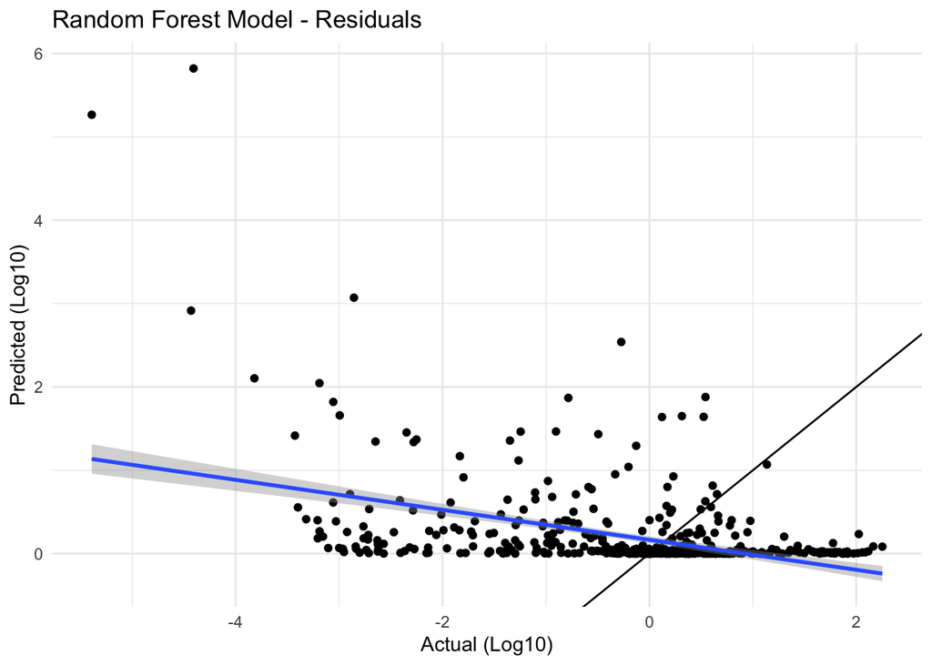

```r
ggplot(residuals, aes(x = logQmean, y = residuals)) +
  geom_point() +
  geom_abline() +
  geom_smooth(method = "lm") +
  labs(title = "Random Forest Model - Residuals",
       x = "Actual (Log10)",
       y = "Predicted (Log10)", subtitle = ) +
  theme_minimal()
```

## Use patchwork to combine the two maps into one figure.

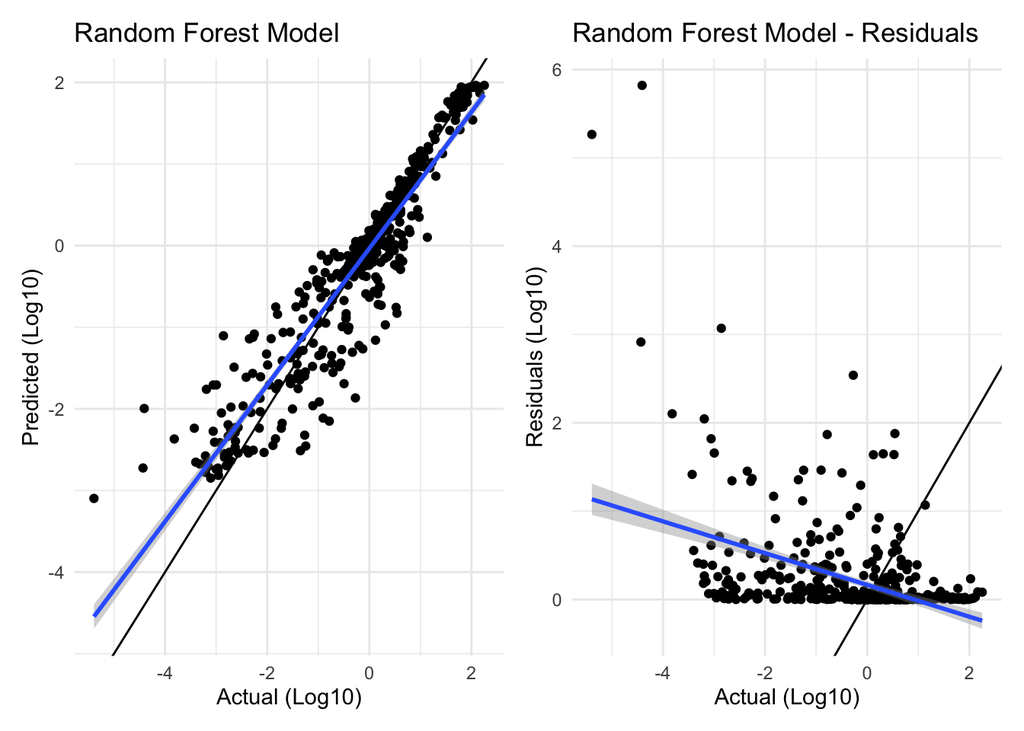

```r
plot1 <- ggplot(full_pred, aes(x = logQmean, y = .pred)) +
  geom_point() +
  geom_abline() +
  geom_smooth(method = "lm") +
  labs(title = "Random Forest Model",
       x = "Actual (Log10)",
       y = "Predicted (Log10)") +
  theme_minimal()

plot2 <- ggplot(residuals, aes(x = logQmean, y = residuals)) +
  geom_point() +
  geom_abline() +
  geom_smooth(method = "lm") +
  labs(title = "Random Forest Model - Residuals",
       x = "Actual (Log10)",
       y = "Residuals (Log10)") +
  theme_minimal()

# Combine the two plots using patchwork
plot1 + plot2
```